# Control Structures

Naomi Tague

January, 2023

# Review DataTypes.Rmd

Two key “take homes”

- working with *factors*
- how to return multiple items from a function using *list*

How do you figure out the rarest fish in our simulated ocean?

Try it - generate a simulated ocean by sampling; and then uses summary to find the rarest fish

# Answer

```r
possible.fish = c("salmon","steelhead","shark","tuna","cod")
catch1 = base::sample(possible.fish, size=20, replace=T)
rarestfish = names(which.min(summary(as.factor(catch1))))
rarestfish
```

```
## [1] "salmon"
```

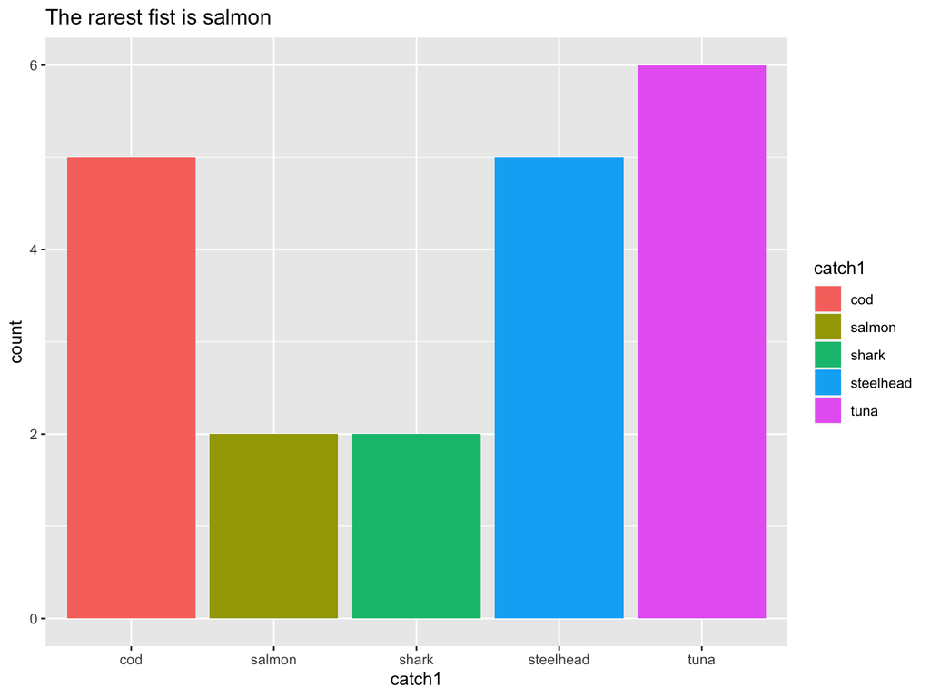

```r
plottitle = sprintf("The rarest fist is %s", rarestfish)
ggplot(data.frame(catch1=catch1), aes(catch1, fill=catch1))+geom_histogram(stat="count")+labs(title=plottitle)
```

# Flow Control (think of steering your program)

Another KEY concept is flow control

Allowing your function to “do” different things depending on a conditions

CLASSIC example is

*IF* then *ELSE*

If you have multiple conditions we can use *case_when*

Here’s a silly simple example of how it works

# Simple example of flow control with if

```r
mycortest  = function(x,y, thresh=0.8) {
  # compute correlation
  res = cor(x,y)
  classification = ifelse(res > thresh, "GOOD", "NotGood")
  return(classification)
}

a = runif(min=1, max=100, n=100)
b = runif(min=1, max=100, n=100)

mycortest(a,b)
```

```
## [1] "NotGood"
```

```r
mycortest(a,a)
```

```
## [1] "GOOD"
```

```r
# this doesn't work - why?
mycortest(a, 1)
```

```
## Error in cor(x, y): incompatible dimensions
```

```r
# useful to add error checking
mycortest  = function(x,y, thresh=0.8) {
  # compute correlation
  if(length(x) != length(y)) {stop("unequal lengths for x and y")}
  res = cor(x,y)
  classification = ifelse(res > thresh, "GOOD", "NotGood")
  return(classification)
}
mycortest(a, 1)
```

```
## Error in mycortest(a, 1): unequal lengths for x and y
```

# Flow control with a simple if

```r
# Simple "IF*
# imagine we are trying to get a tuna  - lets "fish" by sampling
possible.fish = c("salmon","steelhead","shark","tuna","cod")
catch1 = base::sample(possible.fish, size=1, replace=T)
catch1
```

```
## [1] "cod"
```

```r
ifelse(catch1 == "tuna", "success", "tryagain")
```

```
## [1] "tryagain"
```

```r
catch1 = "tuna"
ifelse(catch1 == "tuna", "success", "tryagain")
```

```
## [1] "success"
```

# Multiple Alternatives

What if we have more than one category of fish

grade A, B, C

- steelhead are A,
- tuna are B
- everything else is C

R and other languages have ways to do this multiple alternatives flow control in R an example is

*case_when*

case_when(

condition ~ response,

condition ~ response … )

```r
fish = "steelhead"

case_when((fish =="steelhead")  ~ "A", (fish =="tuna") ~ "B", !(fish == "tuna") & !(fish=="steelhead") ~ "C")
```

```
## [1] "A"
```

```r
# apply to all of our ocean
# start by making a function
classify_fish = function(fish) {
 class=  case_when((fish =="steelhead")  ~ "A", (fish =="tuna") ~ "B", !(fish == "tuna") & !(fish=="steelhead") ~ "C")
 return(class) }

classify_fish("steelhead")
```

```
## [1] "A"
```

```r
classify_fish("cod")
```

```
## [1] "C"
```

```r
# apply to our ocean
possible.fish = c("salmon","steelhead","shark","tuna","cod")
catch2 = base::sample(possible.fish, size=20, replace=T)
catch2
```

```
##  [1] "shark"     "salmon"    "steelhead" "shark"     "tuna"      "steelhead"
##  [7] "steelhead" "tuna"      "salmon"    "cod"       "salmon"    "steelhead"
## [13] "shark"     "steelhead" "salmon"    "salmon"    "tuna"      "salmon"
## [19] "tuna"      "steelhead"
```

```r
classify_fish(catch2)
```

```
##  [1] "C" "C" "A" "C" "B" "A" "A" "B" "C" "C" "C" "A" "C" "A" "C" "C" "B" "C" "B"
## [20] "A"
```

# A more interesting example

Lets imagine that we are monitoring pollution in a lake, and we want to write a function that will let us know (flag) if risk associated with nutrient pollution are high, medium or low

From ecological studies, we know that

*High Risk Conditions*

- risk is high if water temperature is greater than a threshold for more than 5 days, and
- mean nutrient concentration is greater than a high threshold

*Medium Risk Conditions*

- Risk is medium if water temperature is greater than a threshold for more than 5 days and
- mean nutrient concentration is greater than a medium threshold

*Eveything else is low risk*

# Design the function

**Inputs**:

- nutrient concentration for at least 5 days
- temperature for at least 5 days
- thresholds for temperature and nutrient (with default values)

**Output**:

- Mean Nutrient Concentration
- Pollution Risk as “low”, “med” or “high”

Take a look at classify_lake

- example of while
- example of flow control with if..else and case_when

```r
source("../R/classify_lake.R")

# generate some data to try the function
temperature = runif(min=4, max=35, n=30)
nutrient = runif(min=5, max=40, n=30)

# try it
res=classify_lake(temperature=temperature, nutrient=nutrient)

# lets pick some numbers we know should give us a low value
nutrient = runif(min=0, max=5, n=30)
classify_lake(temperature=temperature, nutrient=nutrient)
```

```
## $risk
## [1] "low"
##
## $mean_nutrient
## [1] 2.419575
```

```r
# now try high
# use repeat to generate the same value multiple times
nutrient = rep(50, times=30)
temperature = rep(25, times=30)
classify_lake(temperature=temperature, nutrient=nutrient)
```

```
## $risk
## [1] "high"
##
## $mean_nutrient
## [1] 50
```

# What we’ve learned

- how to write a function (and add error checking)
- how to generate data
- how to repeat in code (different types of looping)
- how to make choices (flow control)

# Assignment

Write a function that takes a vector of fish names and always returns three items

- the most common fish,
- the rarest fish
- the total number of fish

Create an Rmarkdown to demonstrate the use of your function with fish.txt - which is under Data on ESM_262_Examples

Turn in on Gauchospace what your function returns when you run with fish.txt!

*Challenge*: What if we had multiple catches - how would you run your summary function for all of those catches - see below for an example to generate multiple catches You don’t have to run this one in but we will go over in class

```r
# generate some data if we had 10 different fishing days
# some examples of using the purr family of functions

possible.fish = c("salmon","steelhead","shark","tuna","cod")

# lets generate random sample of the number of fish caught on each day
ndays=10
catches = round(runif(min=3, max=400, n=ndays))

# now for each fishing day (and its number of fish caught) - use sample to genreate the fish
catches_res = list(catches) %>% pmap(sample, x=possible.fish, replace=TRUE)
# look at the sample catches
catches_res[[1]]
```

```
##   [1] "shark"     "tuna"      "salmon"    "tuna"      "tuna"      "salmon"
##   [7] "tuna"      "tuna"      "steelhead" "tuna"      "salmon"    "steelhead"
##  [13] "shark"     "tuna"      "tuna"      "steelhead" "salmon"    "cod"
##  [19] "steelhead" "cod"       "tuna"      "shark"     "steelhead" "steelhead"
##  [25] "steelhead" "cod"       "salmon"    "tuna"      "tuna"      "shark"
##  [31] "steelhead" "cod"       "salmon"    "salmon"    "steelhead" "shark"
##  [37] "steelhead" "tuna"      "salmon"    "shark"     "tuna"      "cod"
##  [43] "shark"     "cod"       "steelhead" "cod"       "shark"     "cod"
##  [49] "shark"     "cod"       "salmon"    "shark"     "steelhead" "steelhead"
##  [55] "salmon"    "shark"     "salmon"    "salmon"    "salmon"    "tuna"
##  [61] "shark"     "tuna"      "cod"       "shark"     "steelhead" "shark"
##  [67] "salmon"    "tuna"      "cod"       "cod"       "shark"     "shark"
##  [73] "tuna"      "cod"       "shark"     "salmon"    "cod"       "tuna"
##  [79] "steelhead" "steelhead" "salmon"    "steelhead" "cod"       "shark"
##  [85] "salmon"    "steelhead" "salmon"    "cod"       "shark"     "shark"
```

[output cut: 16 more lines]

```r
catches_res[[10]]
```

```
##  [1] "steelhead" "tuna"      "cod"       "salmon"    "shark"     "steelhead"
##  [7] "cod"       "steelhead" "steelhead" "cod"       "tuna"      "cod"
## [13] "cod"       "cod"       "salmon"    "steelhead" "tuna"      "salmon"
## [19] "tuna"      "tuna"      "salmon"    "shark"     "tuna"      "cod"
## [25] "salmon"    "steelhead" "shark"     "steelhead" "tuna"      "tuna"
## [31] "steelhead" "steelhead" "steelhead" "tuna"      "salmon"    "cod"
## [37] "steelhead" "steelhead" "salmon"    "steelhead" "tuna"      "shark"
## [43] "steelhead" "tuna"      "steelhead" "salmon"    "tuna"      "shark"
## [49] "cod"       "steelhead" "tuna"      "cod"       "tuna"      "steelhead"
## [55] "salmon"    "tuna"      "steelhead" "cod"       "steelhead" "cod"
## [61] "steelhead" "tuna"      "tuna"      "shark"     "cod"       "steelhead"
## [67] "tuna"      "cod"       "steelhead" "tuna"      "salmon"    "shark"
## [73] "tuna"
```

```r
# ok so how do we get the summary (rarest fish, number of fish for all catches in catch_res)?
```